# Cyclistic Case Study Report

Jesslyn

12/13/2021

# Cyclistic Case Study

Cyclistic merupakan sebauh perusahaan fiktif yang menawaerkan peminjaman sepeda. Terdapat tiga *pricing plan* yang ditawarkan oleh Cyclistic: *single-ride passes*, *full-day passes*, dan *annual memberships*. Pelanggan yang membeli *single-ride* atau *full-day passes* disebut sebagai *casual riders*. Pelanggan yang membeli *annual membership* disebut *Cyclistic members*.

Seorang finance analyst dari Cyclistic menyimpulkan bahwa *annual members* lebih menguntungkan daripada *casual riders* walaupun fleksibilitas *pricing plan* membantu Cyclistic menarik banyak pelanggan. Oleh karena itu, jumlah *annual members* ingin dimaksimumkan.

Dibanding menarik pelanggan baru untuk menjadi *annual members*, finance analyst tersebut percaya bahwa terdapat kesempatan yang bagus untuk mengubah *casual riders* menjadi *annual members* . Oleh karena itu, tujuan dari case study ini adalah mencari cara agar dapat menarik *casual riders* ,emkado *annual members*.

## Ask

Terdapat tiga pertanyaan yang perlu dijawab dalam analisis ini agar dapat menemukan cara untuk menerik *casual riders* menjadi *annual members*:  
1. Apa perilaku yang membedakan *casual riders* dengan *annual memebrs*?  
2. Menagapa *casual riders* mau membeli *annual membership*?  
3. Bagaimana cara Cyclistic menggunakan media digital agar dapat mempengaruhi *casual riders* untuk menjadi *annual riders*?

## Prepare

[Dataset](https://divvy-tripdata.s3.amazonaws.com/index.html) yang digunakan dalam case study ini berasal dari Motivate International Inc. dengan [lisensi](https://www.divvybikes.com/data-license-agreement).

## Process

Pada bagian ini, dilakukan *data cleaning*. Berikut ini adalah tahap-tahap *data cleaning* dengan emggunakan R:

1. Mengimport setiap dataset ke RStudio;

```r
data_q1 <- read.csv("Divvy_Trips_2020_Q1.csv")
data_04 <- read.csv("202004-divvy-tripdata.csv")
data_05 <- read.csv("202005-divvy-tripdata.csv")
data_06 <- read.csv("202006-divvy-tripdata.csv")
data_07 <- read.csv("202007-divvy-tripdata.csv")
data_08 <- read.csv("202008-divvy-tripdata.csv")
data_09 <- read.csv("202009-divvy-tripdata.csv")
data_10 <- read.csv("202010-divvy-tripdata.csv")
data_11 <- read.csv("202011-divvy-tripdata.csv")
data_12 <- read.csv("202012-divvy-tripdata.csv")
```

2. Menggabungkan setiap dataset ke dalam satu variabel;

```r
trip_data <- rbind(data_q1, data_04, data_05, data_06, data_07, data_08, data_09, data_10, data_11, data_12)
```

3. Menghilangkan setiap baris yang yang mengandung NA dan memasukkannya ke dalam variabel baru;

```r
no_null_trip_data <- na.omit(trip_data)
```

4. Mengambil setiap baris dengan ended_at > started_at;

```r
no_null_trip_data <- subset(no_null_trip_data, ended_at > started_at)
```

5. Menambah tiga kolom baru pada no_null_trip data, yaitu ride_length (jarak antara ended_at dan started_at), day_of_week (hari pada started_at), dan month (bulan pada started_at).

```r
library(lubridate)
no_null_trip_data$ride_length <- difftime(ymd_hms(no_null_trip_data$ended_at),ymd_hms(no_null_trip_data$started_at), units = "secs")
no_null_trip_data$day_of_week <- wday(as.Date(no_null_trip_data$started_at))
no_null_trip_data$month <- month(as.Date(no_null_trip_data$started_at))
```

## Analyze

Pada bagian ini, dilakukan analisis data. Berikut ini adalah tahap-tahao analisis dengan menggunakan R:

1. Memanggil dplyr dan lubridate yang akan digunakan sepanjang analisis ini;

```r
library(dplyr)
library(lubridate)
```

2. Membuat fungsi modus yang akan digunakan dalam analisis ini:

```r
mode = function(x) {
  data.frame(sort(-table(x)))[1,1]
}
```

3. Mencari hari apa yang paling banyak terdapat peminjaman sepeda dari *casual riders* dan *annual members*. Hal ini dilakukan dengan mencari modus. Keterangan untuk day_of_week: 1 adalah hari Minggu;

```r
mode_day_of_week <- no_null_trip_data %>%
  group_by(member_casual) %>%
  summarise(mode = mode(day_of_week))
print(mode_day_of_week)
```

```
## # A tibble: 2 x 2
##   member_casual mode
##   <chr>         <fct>
## 1 casual        7
## 2 member        4
```

4. Mencari rata-rata jumlah pemakai sepeda per hari;

```r
number_of_riders <- no_null_trip_data %>%
  group_by(day_of_week) %>%
  count(member_casual)
unique_date <- unique(as.Date(no_null_trip_data$started_at))
number_of_days <- data.frame(table(wday(unique_date)))
casual <- filter(number_of_riders, member_casual=="casual")
member<- filter(number_of_riders, member_casual=="member")
casual$mean_riders <- casual$n / number_of_days$Freq
member$mean_riders <- member$n / number_of_days$Freq
mean_riders_per_day <- rbind(casual, member)
print(mean_riders_per_day)
```

```
## # A tibble: 14 x 4
## # Groups:   day_of_week [7]
##    day_of_week member_casual      n mean_riders
##          <dbl> <chr>          <int>       <dbl>
##  1           1 casual        245914       4729.
##  2           2 casual        134652       2640.
##  3           3 casual        130651       2562.
##  4           4 casual        144813       2732.
##  5           5 casual        154371       2913.
##  6           6 casual        191934       3691.
##  7           7 casual        300367       5776.
##  8           1 member        260148       5003.
##  9           2 member        281589       5521.
## 10           3 member        304417       5969.
## 11           4 member        318188       6004.
## 12           5 member        316749       5976.
## 13           6 member        313158       6022.
## 14           7 member        298968       5749.
```

5. Mencari tipe sepeda apa yang paling banyak dipinjam oleh *casual riders* dan *annual members*. Hal ini juga dilakukan dengan mencari modus.

```r
mode_rideable_type <- no_null_trip_data %>%
  group_by(member_casual) %>%
  summarise(mode = mode(rideable_type))
print(mode_rideable_type)
```

```
## # A tibble: 2 x 2
##   member_casual mode
##   <chr>         <fct>
## 1 casual        docked_bike
## 2 member        docked_bike
```

6. Mencari tipe sepeda apa yang paling banyak dipinjam oleh *casual riders* dan *annual members* untuk setiap harinya. Hal ini untuk melihat apakah ada trend. Keterangan untuk day_of_week: 1 adalah hari Minggu;

```r
mode_rideable_type_day_of_week <- no_null_trip_data %>%
  group_by(member_casual, day_of_week) %>%
  summarise(mode = mode(rideable_type))
print(mode_rideable_type_day_of_week)
```

```
## # A tibble: 14 x 3
## # Groups:   member_casual [2]
##    member_casual day_of_week mode
##    <chr>               <dbl> <fct>
##  1 casual                  1 docked_bike
##  2 casual                  2 docked_bike
##  3 casual                  3 docked_bike
##  4 casual                  4 docked_bike
##  5 casual                  5 docked_bike
##  6 casual                  6 docked_bike
##  7 casual                  7 docked_bike
##  8 member                  1 docked_bike
##  9 member                  2 docked_bike
## 10 member                  3 docked_bike
## 11 member                  4 docked_bike
## 12 member                  5 docked_bike
## 13 member                  6 docked_bike
## 14 member                  7 docked_bike
```

7. Mencari rata-rata jumlah pemakai per hari berdasarkan tipe sepeda;

```r
number_of_riders_rideable_type <- no_null_trip_data %>%
  group_by(rideable_type) %>%
  count(member_casual)
mean_riders_rideable_type <- number_of_riders_rideable_type
mean_riders_rideable_type$mean_riders <- number_of_riders_rideable_type$n / 364
print(mean_riders_rideable_type)
```

```
## # A tibble: 6 x 4
## # Groups:   rideable_type [3]
##   rideable_type member_casual       n mean_riders
##   <chr>         <chr>           <int>       <dbl>
## 1 classic_bike  casual          11288        31.0
## 2 classic_bike  member          59248       163.
## 3 docked_bike   casual        1140595      3134.
## 4 docked_bike   member        1810763      4975.
## 5 electric_bike casual         150819       414.
## 6 electric_bike member         223206       613.
```

8. Mencari mean, min, dan max dari ride_length dari *casual riders* dan *annual members*;

```r
mean_min_max<- no_null_trip_data %>%
  group_by(member_casual) %>%
  summarise(mean = mean(ride_length),min = min(ride_length), max =max(ride_length))

mean_min_max$mean <- seconds_to_period(mean_min_max$mean)
mean_min_max$min <- seconds_to_period(mean_min_max$min)
mean_min_max$max <- seconds_to_period(mean_min_max$max)
print(mean_min_max)
```

```
## # A tibble: 2 x 4
##   member_casual mean                  min      max
##   <chr>         <Period>              <Period> <Period>
## 1 casual        47M 49.7377097755252S 1S       108d 15H 30M 24S
## 2 member        15M 37.2204520601538S 1S       65d 3H 13M 31S
```

9. Mencari mean, min, dan max dari ride_length dari *casual riders* dan *annual members* untuk setiap harinya. Hal ini untuk melihat apakah ada trend. Keterangan untuk day_of_week: 1 adalah hari Minggu;

```r
mean_min_max_day_of_week<- no_null_trip_data %>%
  group_by(member_casual, day_of_week) %>%
  summarise(mean = mean(ride_length),min = min(ride_length), max =max(ride_length))
mean_min_max_day_of_week$mean <- seconds_to_period(mean_min_max_day_of_week$mean)
mean_min_max_day_of_week$min <- seconds_to_period(mean_min_max_day_of_week$min)
mean_min_max_day_of_week$max <- seconds_to_period(mean_min_max_day_of_week$max)
print(mean_min_max_day_of_week)
```

```
## # A tibble: 14 x 5
## # Groups:   member_casual [2]
##    member_casual day_of_week mean                  min      max
##    <chr>               <dbl> <Period>              <Period> <Period>
##  1 casual                  1 54M 37.5833868750874S 1S       99d 22H 56M 45S
##  2 casual                  2 46M 45.9344829634911S 1S       32d 1H 24M 36S
##  3 casual                  3 43M 1.11767992590967S 1S       48d 6H 24M 51S
##  4 casual                  4 43M 1.63424554425364S 1S       51d 21H 3M 21S
##  5 casual                  5 46M 52.9658290741136S 1S       108d 15H 30M 24S
##  6 casual                  6 45M 48.2446361770185S 1S       81d 11H 23M 25S
##  7 casual                  7 48M 55.6852883306087S 1S       45d 14H 21M 42S
##  8 member                  1 18M 6.96443178498384S 1S       40d 18H 40M 2S
##  9 member                  2 14M 51.1490860793568S 1S       65d 3H 13M 31S
## 10 member                  3 14M 24.0778898681742S 1S       10d 11H 45M 4S
## 11 member                  4 14M 37.4394634618526S 1S       28d 15H 51M 0S
## 12 member                  5 14M 38.4655452740184S 1S       25d 2H 36M 7S
## 13 member                  6 15M 21.6452078503503S 1S       29d 19H 56M 14S
## 14 member                  7 17M 46.9771346766208S 1S       55d 0H 17M 31S
```

10. Mencari jumlah pemakai untuk setiap bulan.

```r
number_of_riders_per_month <- no_null_trip_data %>%
  group_by(month) %>%
  count(member_casual)
print(number_of_riders_per_month)
```

```
## # A tibble: 24 x 3
## # Groups:   month [12]
##    month member_casual      n
##    <dbl> <chr>          <int>
##  1     1 casual          7785
##  2     1 member        136099
##  3     2 casual         12860
##  4     2 member        126715
##  5     3 casual         27625
##  6     3 member        115593
##  7     4 casual         23566
##  8     4 member         61054
##  9     5 casual         86693
## 10     5 member        113079
## # ... with 14 more rows
```

## Share

Pada bagian ini, dilakukasi visualisasi data. Berikut ini adalah beberapa plot beserta penjelasannya:

1.Jumlah pemakai berdasarkan hari

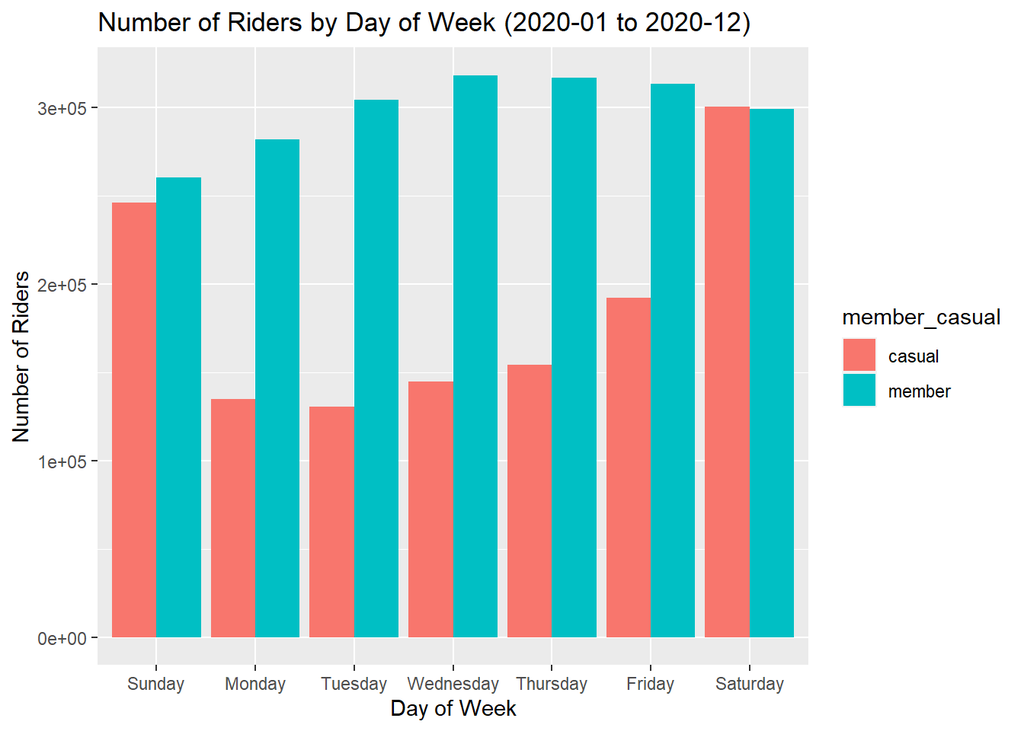

```r
library(ggplot2)

ggplot(data = number_of_riders, aes(x = factor(day_of_week), y = n, fill = member_casual)) + geom_bar(position ="dodge", stat="identity") +
  scale_x_discrete(name = "Day of Week" ,labels = c("1"="Sunday", "2"="Monday", "3"="Tuesday", "4"="Wednesday", "5"="Thursday", "6"="Friday", "7"="Saturday")) +
  ylab("Number of Riders") +
  labs(title = "Number of Riders by Day of Week (2020-01 to 2020-12)")
```

Plot di atas memberikan beberapa informasi berikut:

1. Jumlah *casual riders* terbanyak pada hari *weekends* dalam peiode Januari 2020 hingga Desember 2020;
2. Jumlah *casual riders* jauh lebih rendah pada hari *weekdays* dalam periode Januari 2020 hingga Desember 2020;
3. Jumlah *annual members* terbanyak pada hari *weekdays* dalam periode Januari 2020 hingga Desember 2020;
4. Jumlah *annual members* pada hari *weekends* lebih rendah dibanding pada hari *weekdays*, tetapi perbedaannya tidak begitu jauh.
2. Rata-rata jumlah pemakai berdasarkan hari

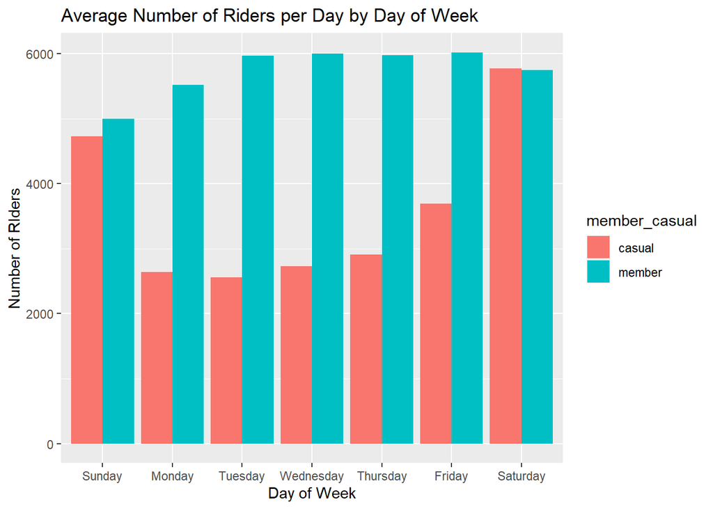

```r
ggplot(data = mean_riders_per_day, aes(x = factor(day_of_week), y = mean_riders, fill = member_casual)) + geom_bar(position ="dodge", stat="identity") +
  scale_x_discrete(name = "Day of Week" ,labels = c("1"="Sunday", "2"="Monday", "3"="Tuesday", "4"="Wednesday", "5"="Thursday", "6"="Friday", "7"="Saturday")) +
  ylab("Number of RIders") +
  labs(title = "Average Number of Riders per Day by Day of Week")
```

Plot di atas memberikan beberapa informasi berikut:

1. Rata-rata jumlah *casual riders* terbesar berada pada hari *weekends*;
2. Rata-rata jumlah *casual riders* jauh lebih rendah pada hari *weekdays* ;
3. Rata-rata jumlah *annual members* terbesar berada pada hari *weekdays*;
4. Rata-rata jumlah *annual members* pada hari *weekends* lebih rendah dibanding pada hari *weekdays*, tetapi perbedaannya tidak begitu jauh.
3. Jumlah pemakai berdasarkan tipe sepeda

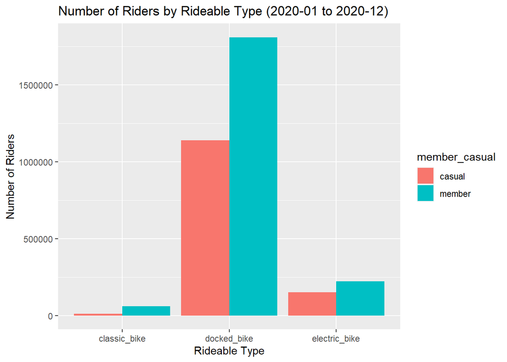

```r
ggplot(data = number_of_riders_rideable_type, aes(x = rideable_type, y = n, fill = member_casual)) +
  geom_bar(position ="dodge", stat="identity") +
  labs(title = "Number of Riders by Rideable Type (2020-01 to 2020-12)") +
  xlab("Rideable Type") +
  ylab("Number of Riders")
```

Plot di atas memberikan beberapa informasi berikut:

1. *Casual riders* paling banyak menggunakan *docked bike* dalam peiode Januari 2020 hingga Desember 2020;
2. *Annual members* paling banyak menggunakan *dockded bike*dalam peiode Januari 2020 hingga Desember 2020;
3. *Docked bike* merupakan tipe sepeda yang paling populer dalam peiode Januari 2020 hingga Desember 2020.
4. Rata-rata jumlah pemakai berdasarkan tipe sepeda

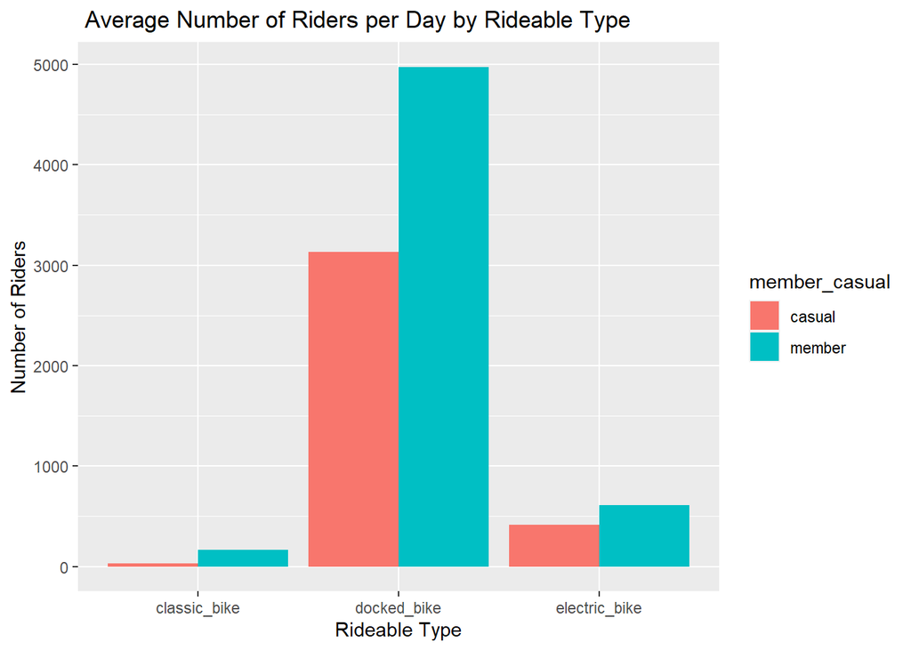

```r
ggplot(data = mean_riders_rideable_type, aes(x = rideable_type, y = mean_riders, fill = member_casual)) +
  geom_bar(position ="dodge", stat="identity") +
  labs(title = " Average Number of Riders per Day by Rideable Type") +
  xlab("Rideable Type") +
  ylab("Number of Riders")
```

Plot di atas memberikan beberapa informasi berikut:

1. *casual riders* paling banyak menggunakan *docked bike*;
2. *Annual members* paling banyak menggunakan *dockded bike*;
3. *Docked bike* merupakan tipe sepeda yang paling populer.
5. Jumlah pemakai berdasarkan bulan

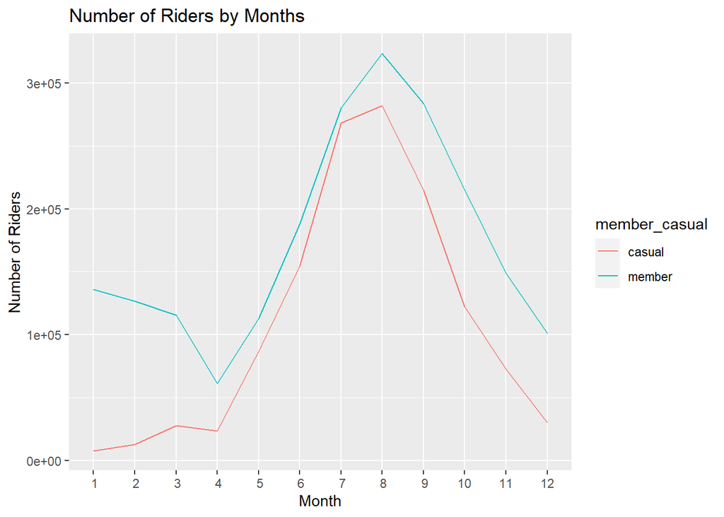

```r
ggplot(data = number_of_riders_per_month, aes(x = as.numeric(month), y = n, color = member_casual)) + geom_line() + labs(title = "Number of Riders by Months") +
  scale_x_discrete(name = "Month", limits = c(1,2,3,4,5,6,7,8,9,10,11,12)) +
  ylab("Number of Riders")
```

Plot di atas memberikan beberapa informasi berikut:

1. Terjadi lonjakan jumlah *casual riders* pada liburan musim panas;
2. Terjadi lonjakan jumlah *annual members* pada libruan musim panas;
3. Selama 12 bulan, jumlah *annual memberss* selalu lebih banyak daripada jumlah *casual riders*.

## Act

Pada tahap ini, diberikan rekomendasi-rekomendasi berdasarkan hasil analisis. Untuk dapat memberikan rekomendasi, pertanyaan-pertanyaan pada tahap **Ask** perlu dijawab. Berikut ini adalah jawaban berdasarkan hasil analisis:

1. *Casual riders* cenderung melakukan peminjaman sepeda pada hari libur, sedangkan *annual members* cenderung melakukan peminjaman sepeda pada hari kerja. Selain itu, *casual riders* cenderung untuk bersepeda dalam waktu yang lama dibandingkan dengan *annual members*. Kemungkinan besar hal ini terjadi karena *casual riders* menggunakan sepeda untuk rekereasi, sedangkan *annual members* menggunakan sepeda untuk kegiatan sehari-hari.
2. Alasan yang mungkin untuk *casual_riders* menjadi *annual members* adalah *annual membership* sesuai dengan kebutuhan mereka terkait penggunaan sepeda. Jika *casual riders* menggunakan sepeda untuk sehari-hari, maka *casual riders* sangat mungkin untuk membeli *annual membership*.
3. Cyclistic dapat menggunakan media digital untuk melakukan promosi.

Berdasarkan jawaban di atas, saya memberikan beberapa rekomendasi berikut:

1. Membuat *pricing plans* baru yang menargetkan pelanggan yang menggunakan sepeda di hari *weekends*. Hal itu bisa *annual membership* khusus untuk penggunaaan di hari *weekends* dan/atau *weekends passes*;
2. Membuat sistem *rewards* berdasarkan penggunaan sepeda sehingga dapat menarik pelanggan untuk tetap melakukan peminjaman sepeda. Hal ini untuk mendorong *casual riders* untuk membeli *annual membership*;
3. Melihat *casual riders* yang cenderung melakukan peminjaman sepeda pada hari libur, Cyclistic dapat mencoba untuk melakukan promosi melaui media digital pada musim liburan atau hari *weekends*